# Sesta data challenge

Denise Cantoni

2026-10-28

# PRIMA DOMANDA

How do their transfer sizes differ?

```r
library(usethis)
library(tidyverse)
library(httr2)

edit_r_environ()
```

```r
api_key <- Sys.getenv("ETHERSCAN_API_KEY")
```

```r
USDC = "0xa0b86991c6218b36c1d19d4a2e9eb0ce3606eb48"
USDT = "0xdac17f958d2ee523a2206206994597c13d831ec7"
DAI  = "0x6b175474e89094c44da98b954eedeac495271d0f"
```

```r
get_transfers <- function(address) {

  response <- request("https://api.etherscan.io/v2/api") |>
    req_url_query(
      chainid = 1,
      module = "account",
      action = "tokentx",   #ERC-20
      #utilizzo contractaddress perchè ho a disposizione uno smart contract
      contractaddress = address,
      startblock = 0,
      endblock = 99999999,
      page = 1,
      offset = 1000,
      sort = "asc",
      apikey = api_key
    ) |>
    req_perform() |>
    resp_body_json(simplifyVector = TRUE)

  response
}

usdc <- get_transfers(USDC)
usdt <- get_transfers(USDT)
dai  <- get_transfers(DAI)


write_rds(usdc, "data/usdc.rds")
write_rds(usdt, "data/usdt.rds")
write_rds(dai, "data/dai.rds")
```

```r
usdc <- read_rds("data/usdc.rds")
usdt <- read_rds("data/usdt.rds")
dai  <- read_rds("data/dai.rds")
```

```r
tidy_table <- function(name) {
  name$result |>
  as_tibble() |>
  transmute(
    tokenName,
    value,
    amount = as.numeric(value) / 10^as.numeric(tokenDecimal),
    from,
    to,
    tokenSymbol,
    tokenDecimal
  )
}

transactions_usdc <- tidy_table(usdc)
transactions_usdt <- tidy_table(usdt)
transactions_dai <- tidy_table(dai)

transactions_usdc
```

```
## # A tibble: 1,000 × 7
##    tokenName value     amount from                to    tokenSymbol tokenDecimal
##    <chr>     <chr>      <dbl> <chr>               <chr> <chr>       <chr>
##  1 USDC      20000000    20   0x0000000000000000… 0x55… USDC        6
##  2 USDC      1000000      1   0x55fe002aeff02f77… 0x4d… USDC        6
##  3 USDC      1000000      1   0x55fe002aeff02f77… 0x4a… USDC        6
##  4 USDC      200000       0.2 0x55fe002aeff02f77… 0xe7… USDC        6
##  5 USDC      1000000      1   0x55fe002aeff02f77… 0x50… USDC        6
##  6 USDC      1000000      1   0x50eddb12e31ce6ae… 0x6f… USDC        6
##  7 USDC      100000       0.1 0x55fe002aeff02f77… 0xe7… USDC        6
##  8 USDC      400000       0.4 0x6f803466bcd17f44… 0x19… USDC        6
##  9 USDC      100000000  100   0x0000000000000000… 0x55… USDC        6
## 10 USDC      1000000      1   0x55fe002aeff02f77… 0xe1… USDC        6
## # ℹ 990 more rows
```

```r
transactions_usdt
```

```
## # A tibble: 1,000 × 7
##    tokenName  value       amount from             to    tokenSymbol tokenDecimal
##    <chr>      <chr>        <dbl> <chr>            <chr> <chr>       <chr>
##  1 Tether USD 100000000      100 0x36928500bc1dc… 0xc6… USDT        6
##  2 Tether USD 10000000        10 0xc6cde7c39eb2f… 0x2b… USDT        6
##  3 Tether USD 99900000000  99900 0x36928500bc1dc… 0xc6… USDT        6
##  4 Tether USD 10000000        10 0xc6cde7c39eb2f… 0x2b… USDT        6
##  5 Tether USD 20000000        20 0x2b2c9153acc40… 0x9f… USDT        6
##  6 Tether USD 10000000        10 0xc6cde7c39eb2f… 0x2b… USDT        6
##  7 Tether USD 10000000        10 0x2b2c9153acc40… 0x9f… USDT        6
##  8 Tether USD 100000000      100 0xc6cde7c39eb2f… 0x2b… USDT        6
##  9 Tether USD 100000000      100 0x2b2c9153acc40… 0x9f… USDT        6
## 10 Tether USD 20000000        20 0xc6cde7c39eb2f… 0x5a… USDT        6
## # ℹ 990 more rows
```

```r
transactions_dai
```

```
## # A tibble: 1,000 × 7
##    tokenName      value amount from               to    tokenSymbol tokenDecimal
##    <chr>          <chr>  <dbl> <chr>              <chr> <chr>       <chr>
##  1 Dai Stablecoin 0          0 0x000000000000000… 0xb9… DAI         18
##  2 Dai Stablecoin 0          0 0x000000000000000… 0xe9… DAI         18
##  3 Dai Stablecoin 0          0 0x000000000000000… 0x0c… DAI         18
##  4 Dai Stablecoin 0          0 0x000000000000000… 0x0c… DAI         18
##  5 Dai Stablecoin 0          0 0x000000000000000… 0x8d… DAI         18
##  6 Dai Stablecoin 0          0 0x000000000000000… 0x8d… DAI         18
##  7 Dai Stablecoin 0          0 0x000000000000000… 0x8d… DAI         18
##  8 Dai Stablecoin 0          0 0x000000000000000… 0x03… DAI         18
##  9 Dai Stablecoin 0          0 0x000000000000000… 0xa4… DAI         18
## 10 Dai Stablecoin 0          0 0x000000000000000… 0xad… DAI         18
## # ℹ 990 more rows
```

```r
transactions <- bind_rows(
  USDC = transactions_usdc,
  USDT = transactions_usdt,
  DAI = transactions_dai,
  .id = "stablecoin"
)

info <- transactions |>
  group_by(stablecoin) |>
  summarise(
    numero_trasferimenti = n(),
    among_total = sum(amount, na.rm = TRUE),
    media = mean(amount, na.rm = TRUE),
    mediana = median(amount, na.rm = TRUE),
    minimo = min(amount, na.rm = TRUE),
    massimo = max(amount, na.rm = TRUE),
    .groups = "drop"
  )

info
```

```
## # A tibble: 3 × 7
##   stablecoin numero_trasferimenti among_total   media mediana   minimo   massimo
##   <chr>                     <int>       <dbl>   <dbl>   <dbl>    <dbl>     <dbl>
## 1 DAI                        1000    2623383.   2623.    20.0 0          269071.
## 2 USDC                       1000  113577283. 113577.   300.  0        10000000
## 3 USDT                       1000  265176828. 265177.  6088.  0.000002 30000000
```

Dai dati emerge una differenza tra le tre stablecoin in termini di importo dei trasferimenti. DAI presenta gli importi più bassi, con una mediana di circa 20 unità, mentre USDC si colloca in una posizione intermedia, con una mediana di circa 300. USDT registra invece gli importi più elevati, con una mediana superiore a 6.087 unità.

Per tutte e tre le stablecoin, la media è molto più alta della mediana. Questo indica che la maggior parte dei trasferimenti ha importi bassi, mentre poche transazioni di valore elevato aumentano notevolmente la media.

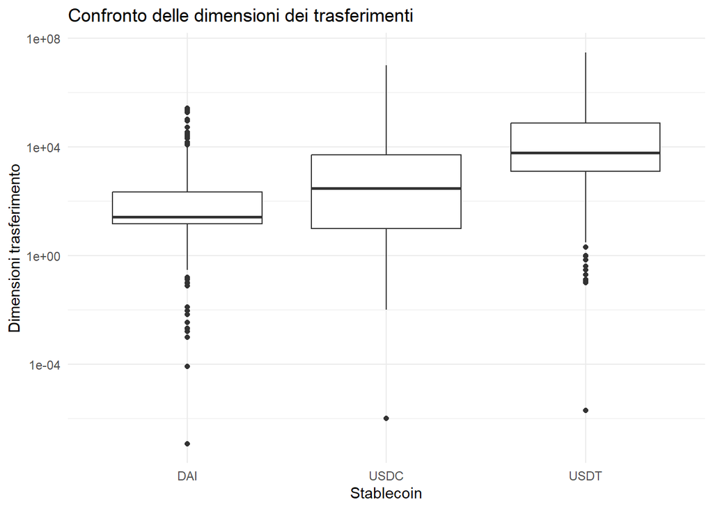

```r
confronto_transazioni <- ggplot(transactions, aes(x = stablecoin, y = amount)) +
  geom_boxplot() +
  scale_y_log10() +
  labs(
    title = "Confronto delle dimensioni dei trasferimenti",
    x = "Stablecoin",
    y = "Dimensioni trasferimento"
  ) +
  theme_minimal()

confronto_transazioni
```

Il boxplot mostra che lo stablecoin con trasferimenti generalmente più grandi è USDT, mentre DAI è quello con trasferimenti più piccoli. Questo si può notare osservando l’altezza della mediana.

Si nota anche una differenza nella variabilità degli importi. DAI presenta un box più schiacciato e uno scarto interquartile più piccolo rispetto agli altri due stablecoin, mentre USDC ha lo scarto interquartile più ampio e quindi una maggiore variabilità nella parte centrale della distribuzione. DAI presenta però diversi valori anomali, che indicano la presenza di trasferimenti molto più piccoli o molto più grandi rispetto alla maggior parte dei trasferimenti dello stesso token.

In conclusione, le tre stablecoin differiscono sia per la dimensione tipica dei trasferimenti sia per la loro variabilità.

# SECONDA DOMANDA

How much transfer volume does each stablecoin generate?

```r
#quanti token vengono trasferiti complessivamente per USDC, USDT e DAI (somma importi per ciascun stablecoin)

tot_volume <- transactions |>
  group_by(stablecoin) |>
  summarise(
    volume_totale = sum(amount)
  )

tot_volume
```

```
## # A tibble: 3 × 2
##   stablecoin volume_totale
##   <chr>              <dbl>
## 1 DAI             2623383.
## 2 USDC          113577283.
## 3 USDT          265176828.
```

Complessivamente il volume totale trasferito tramite USDT risulta nettamente superiore rispetto a quello delle altre stablecoin. Nello specifico, il volume di USDT supera di oltre il doppio quello di USDC ed è circa cento volte più elevato di quello di DAI. Poiché il numero di trasferimenti analizzato è identico per tutti e tre gli stablecoin (1000), questa forte differenza nei volumi evidenzia una differenza evidente nella dimensione media dei singoli trasferimenti.

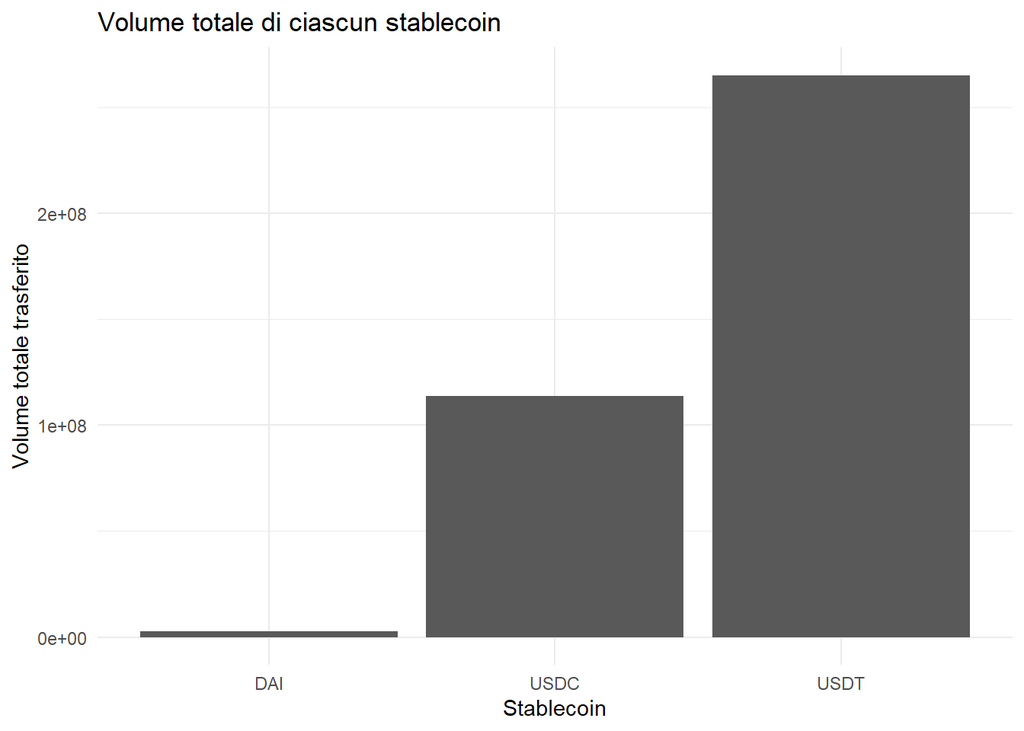

```r
grafico_volume <-ggplot(tot_volume, aes(x = stablecoin, y = volume_totale)) +
  geom_col() +
  labs(
    title = "Volume totale di ciascun stablecoin",
    x = "Stablecoin",
    y = "Volume totale trasferito"
  ) +
  theme_minimal()

grafico_volume
```

Il grafico a barre rende ancora più evidente la differenza evidenziata nella tabella riassuntiva: la barra relativa a DAI risulta quasi impercettibile rispetto all’asse y, mentre USDC raggiunge poco più di 100 milioni e USDT supera anche i 250 milioni. Il grafico conferma quindi come, a parità di transazioni effettuate, il volume complessivo appartenga principalmente dallo stablecoin USDT.